# End-to-End Attrition Analysis: Leveraging EDA and SQL for Diagnostic Insights and Targeted Retention Strategy.

## Project Goal and Overview

The primary goal of this project is to conduct a diagnostic analysis of the employee attrition problem using an HR dataset. The project leverages a dual approach: first, a preparatory Exploratory Data Analysis (EDA) to clean and engineer features, and second, a rigorous SQL-first methodology using SQLite3 database to calculate attrition rates and uncover the root causes of turnover. The final output provides actionable, data-backed insights for HR retention strategies.

#### Steps Taken and Expected Outcome

| **Phase** | **Steps Taken** | **Expected Outcome** |
| --- | --- | --- |
| **Part 1: EDA & Preparation** | Data retrieval, Data preprossesing, Feature engg & EDA, Correlation analysis and Key insights. | A cleaned, structured dataset ready for SQL ingestion, and initial hypotheses on attrition drivers. |
| **Part 2: SQL Implementation** | Creating a SQLite3 DB, Calculating overall and segmented attrition rates (by Gender, Dept, Age, etc.), Deep-dive querying to explore specific drivers (e.g., high-earner turnover, impact of overtime). | A fully documented analysis with clear, quantitative results and specific risk factor identification. |
| **Communication** | Utilizing markdown cells for thought process and observations in part 2; commenting all code for readability. | A transparent, reproducible, and easily reviewable final report. |

## Part 1: Exploratory Data Analysis (EDA) and Data Preparation

This initial phase focused on preparing the HR dataset for reliable SQL analysis.

#### Initial High-Level Findings from EDA

The initial visual and statistical exploration highlighted strong correlations for further SQL investigation:

- High Attrition: Younger employees and those with short tenure were the highest flight risk.
- Correlating Factors: Overtime, low Monthly Income, and low scores on Environment Satisfaction were strongly associated with attrition.

#### Step 1 (Data Retreival)

Goal: Import libraries, load dataset, explore structure, datatypes, and target (attrition).

```python
import pandas as pd
import numpy as np
import seaborn as sns
import sqlite3
import matplotlib.pyplot as plt
```

```python
# Load the HR Attrition dataset
csv_path = "C:/Users/rajri/Downloads/WA_Fn-UseC_-HR-Employee-Attrition.csv"
df = pd.read_csv(csv_path)

print("✅ File loaded successfully!")
print("Shape:", df.shape)
df.info()
df.head()
df.describe(include='all')
```

```
✅ File loaded successfully!
Shape: (1470, 35)
<class 'pandas.core.frame.DataFrame'>
RangeIndex: 1470 entries, 0 to 1469
Data columns (total 35 columns):
 #   Column                    Non-Null Count  Dtype
---  ------                    --------------  -----
 0   Age                       1470 non-null   int64
 1   Attrition                 1470 non-null   object
 2   BusinessTravel            1470 non-null   object
 3   DailyRate                 1470 non-null   int64
 4   Department                1470 non-null   object
 5   DistanceFromHome          1470 non-null   int64
 6   Education                 1470 non-null   int64
 7   EducationField            1470 non-null   object
```

[output cut: 29 more lines]

|  | Age | Attrition | BusinessTravel | DailyRate | Department | DistanceFromHome | Education | EducationField | EmployeeCount | EmployeeNumber | ... | RelationshipSatisfaction | StandardHours | StockOptionLevel | TotalWorkingYears | TrainingTimesLastYear | WorkLifeBalance | YearsAtCompany | YearsInCurrentRole | YearsSinceLastPromotion | YearsWithCurrManager |
| --- | --- | --- | --- | --- | --- | --- | --- | --- | --- | --- | --- | --- | --- | --- | --- | --- | --- | --- | --- | --- | --- |
| count | 1470.000000 | 1470 | 1470 | 1470.000000 | 1470 | 1470.000000 | 1470.000000 | 1470 | 1470.0 | 1470.000000 | ... | 1470.000000 | 1470.0 | 1470.000000 | 1470.000000 | 1470.000000 | 1470.000000 | 1470.000000 | 1470.000000 | 1470.000000 | 1470.000000 |
| unique | NaN | 2 | 3 | NaN | 3 | NaN | NaN | 6 | NaN | NaN | ... | NaN | NaN | NaN | NaN | NaN | NaN | NaN | NaN | NaN | NaN |
| top | NaN | No | Travel_Rarely | NaN | Research & Development | NaN | NaN | Life Sciences | NaN | NaN | ... | NaN | NaN | NaN | NaN | NaN | NaN | NaN | NaN | NaN | NaN |
| freq | NaN | 1233 | 1043 | NaN | 961 | NaN | NaN | 606 | NaN | NaN | ... | NaN | NaN | NaN | NaN | NaN | NaN | NaN | NaN | NaN | NaN |
| mean | 36.923810 | NaN | NaN | 802.485714 | NaN | 9.192517 | 2.912925 | NaN | 1.0 | 1024.865306 | ... | 2.712245 | 80.0 | 0.793878 | 11.279592 | 2.799320 | 2.761224 | 7.008163 | 4.229252 | 2.187755 | 4.123129 |
| std | 9.135373 | NaN | NaN | 403.509100 | NaN | 8.106864 | 1.024165 | NaN | 0.0 | 602.024335 | ... | 1.081209 | 0.0 | 0.852077 | 7.780782 | 1.289271 | 0.706476 | 6.126525 | 3.623137 | 3.222430 | 3.568136 |
| min | 18.000000 | NaN | NaN | 102.000000 | NaN | 1.000000 | 1.000000 | NaN | 1.0 | 1.000000 | ... | 1.000000 | 80.0 | 0.000000 | 0.000000 | 0.000000 | 1.000000 | 0.000000 | 0.000000 | 0.000000 | 0.000000 |
| 25% | 30.000000 | NaN | NaN | 465.000000 | NaN | 2.000000 | 2.000000 | NaN | 1.0 | 491.250000 | ... | 2.000000 | 80.0 | 0.000000 | 6.000000 | 2.000000 | 2.000000 | 3.000000 | 2.000000 | 0.000000 | 2.000000 |
| 50% | 36.000000 | NaN | NaN | 802.000000 | NaN | 7.000000 | 3.000000 | NaN | 1.0 | 1020.500000 | ... | 3.000000 | 80.0 | 1.000000 | 10.000000 | 3.000000 | 3.000000 | 5.000000 | 3.000000 | 1.000000 | 3.000000 |
| 75% | 43.000000 | NaN | NaN | 1157.000000 | NaN | 14.000000 | 4.000000 | NaN | 1.0 | 1555.750000 | ... | 4.000000 | 80.0 | 1.000000 | 15.000000 | 3.000000 | 3.000000 | 9.000000 | 7.000000 | 3.000000 | 7.000000 |
| max | 60.000000 | NaN | NaN | 1499.000000 | NaN | 29.000000 | 5.000000 | NaN | 1.0 | 2068.000000 | ... | 4.000000 | 80.0 | 3.000000 | 40.000000 | 6.000000 | 4.000000 | 40.000000 | 18.000000 | 15.000000 | 17.000000 |

11 rows × 35 columns

The dataset contains HR records with both numeric and categorical variables describing employee demographics, job details, and satisfaction scores. The target variable Attrition indicates whether an employee left the organization.

#### Step 2 (Data Preprocessing)

Goal: Handle missing values, duplicates, outliers, encode categorical variables and ensure correct datatypes.

```python
# Missing values
df.isna().sum().sort_values(ascending=False)

# Drop duplicates
df = df.drop_duplicates()

# Handle data types
cat_cols = df.select_dtypes(include='object').columns
num_cols = df.select_dtypes(exclude='object').columns

# Encode Attrition
df['Attrition_Flag'] = df['Attrition'].map({'Yes':1, 'No':0})

# Convert other categoricals to category type
for col in cat_cols:
    df[col] = df[col].astype('category')

# Outlier detection
def iqr_outliers(s, k=1.5):
    q1, q3 = s.quantile([0.25,0.75])
    iqr = q3-q1
    return ((s < q1 - k*iqr) | (s > q3 + k*iqr))

outlier_summary = {col: iqr_outliers(df[col]).sum() for col in num_cols}
sorted(outlier_summary.items(), key=lambda x: -x[1])[:10]
```

```
[('TrainingTimesLastYear', 238),
 ('PerformanceRating', 226),
 ('MonthlyIncome', 114),
 ('YearsSinceLastPromotion', 107),
 ('YearsAtCompany', 104),
 ('StockOptionLevel', 85),
 ('TotalWorkingYears', 63),
 ('NumCompaniesWorked', 52),
 ('YearsInCurrentRole', 21),
 ('YearsWithCurrManager', 14)]
```

#### Step 3 (Feature Engineering & EDA)

Goal: Create derived features (tenure, age groups, income bins), perform univariate (1-D) and bivariate (2-D) exploration, and identify correlation patterns.

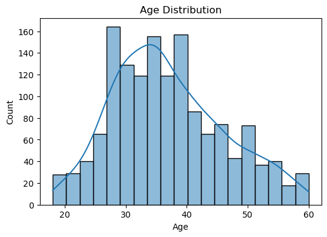

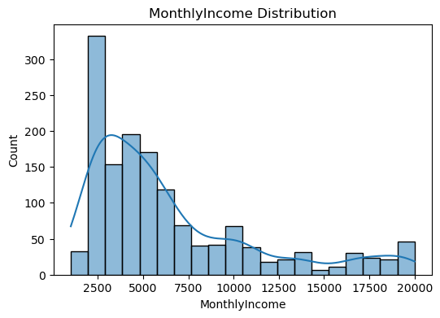

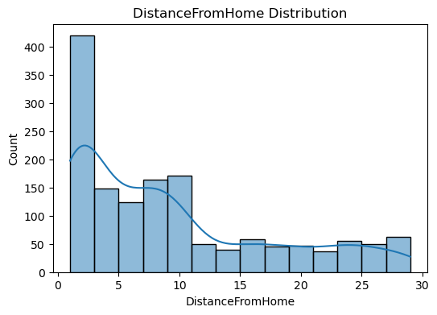

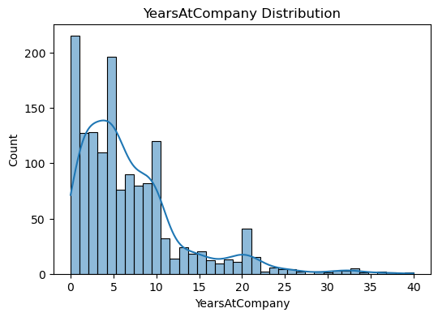

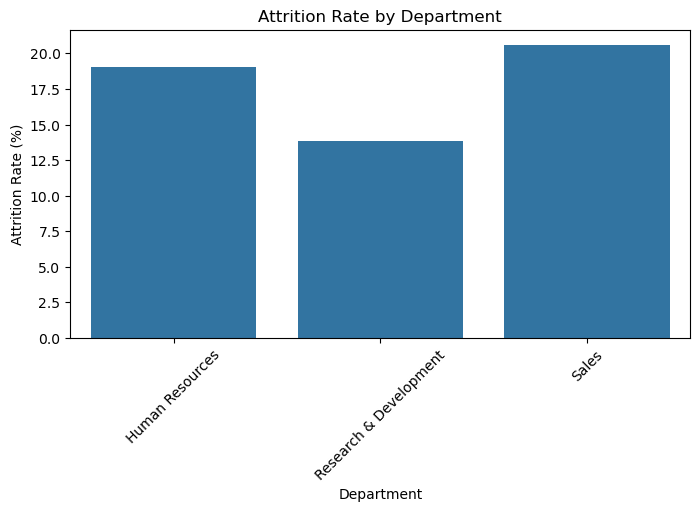

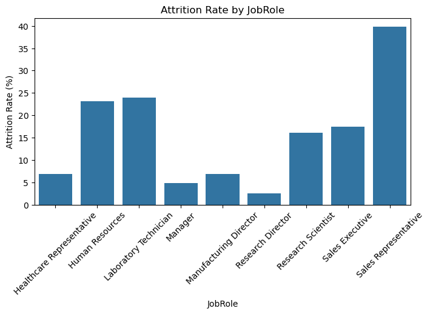

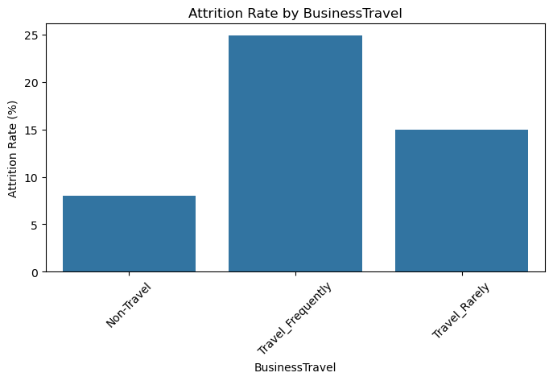

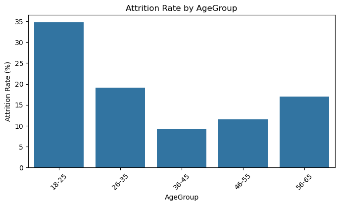

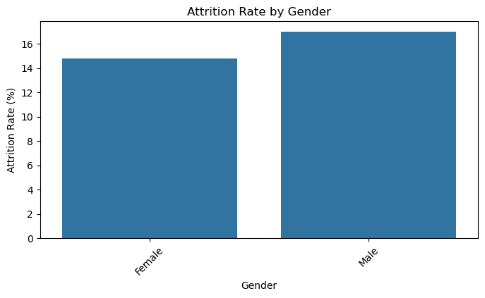

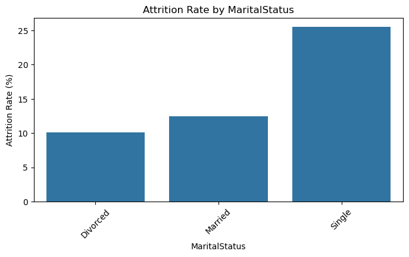

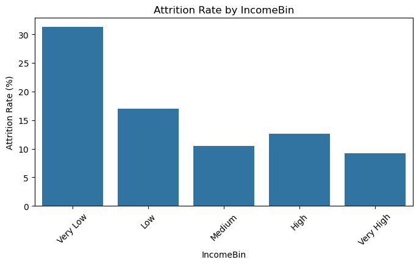

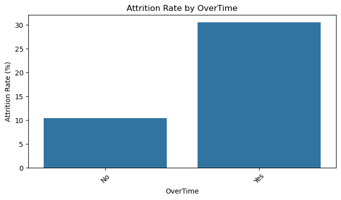

```python
# Feature engineering & EDA
df['Tenure_Years'] = df['YearsAtCompany']
df['AgeGroup'] = pd.cut(df['Age'], bins=[18,25,35,45,55,65], labels=['18-25','26-35','36-45','46-55','56-65'])
df['IncomeBin'] = pd.qcut(df['MonthlyIncome'], q=5, labels=['Very Low','Low','Medium','High','Very High'])

# 1D exploration
for col in ['Age','MonthlyIncome','DistanceFromHome','YearsAtCompany']:
    plt.figure(figsize=(6,4))
    sns.histplot(df[col], kde=True)
    plt.title(f'{col} Distribution')
    plt.show()

# 2D exploration vs target
def attrition_rate(col):
    temp = df.groupby(col)['Attrition_Flag'].mean().sort_values(ascending=False)
    temp = temp * 100
    plt.figure(figsize=(8,4))
    sns.barplot(x=temp.index, y=temp.values)
    plt.title(f'Attrition Rate by {col}')
    plt.ylabel('Attrition Rate (%)')
    plt.xticks(rotation=45)
    plt.show()
    return temp

for feature in ['Department','JobRole','BusinessTravel','AgeGroup','Gender','MaritalStatus','IncomeBin','OverTime']:
    attrition_rate(feature)
```